# TS703 Metodología Investigación Cuantitativa Correlaciones estadísticas

Daniel Quinteros Rojas Trabajo Social Universidad Arturo Prat

Iquique, 22 de marzo de 2021

## Paso 1: Crear base de datos

[figure not shown]

Para comprender el concepto de correlación, vamos a analizar los datos disponibles sobre la pandemia del Covid-19 a nivel internacional. Para ello, utilizaremos los datos que elabora el proyecto [Our World in Data, de la Universidad de Oxford (Reino Unido)](https://ourworldindata.org/coronavirus). Si haces click en el link anterior, podrás entrar al sitio en inglés, pero también descargar los datos y trabajarlos directamente desde el tercer link *Download Dataset*. Para ahorrar tiempo, puedes ejecutar la siguiente sintaxis y obtener los datos directamente desde su repositorio de GitHub, con datos actualizados diariamente (**ATENCIÓN:** *la actualización implica que los datos pueden presentar variaciones de un momento a otro*):

```r
covid <- read.csv(file = ("https://raw.githubusercontent.com/owid/covid-19-data/master/public/data/owid-covid-data.csv"), header=TRUE, sep=",", fileEncoding = "UTF-8")
```

**NOTA:** *los datos incluídos acá son los reportados hasta el día 22 de marzo a las 10:00 hrs. (Chile), los que son actualizados constantemente*

## Paso 2: Explorar los datos

El primer paso para analizar cualquier tipo de datos estadísticos, es utilizar las herramientas de la Estadística Descriptiva, que usted ya conoce. Pero antes, es importante conocer más detalles sobre el objeto de R sobre el cual realizaremos el análisis.

### 2.1 Descripción de la base de datos

```r
# a) Tipo de objeto (pueden hacerlo para cada uno de los objetos que vayan creando)
class(covid)
```

```
## [1] "data.frame"
```

```r
# b)Variables que contiene (sólo para data.frame)
names(covid)
```

```
##  [1] "iso_code"
##  [2] "continent"
##  [3] "location"
##  [4] "date"
##  [5] "total_cases"
##  [6] "new_cases"
##  [7] "new_cases_smoothed"
##  [8] "total_deaths"
##  [9] "new_deaths"
## [10] "new_deaths_smoothed"
## [11] "total_cases_per_million"
## [12] "new_cases_per_million"
## [13] "new_cases_smoothed_per_million"
## [14] "total_deaths_per_million"
## [15] "new_deaths_per_million"
```

[output cut: 44 more lines]

```r
# c) Cantidad de columnas (variables) (sólo para data.frame)
ncol(covid)
```

```
## [1] 59
```

```r
# d) Cantidad de filas (casos) (sólo para data.frame)
nrow(covid)
```

```
## [1] 76411
```

```r
# e) Cantidad de filas y columnas (sólo para data.frame)
dim(covid)
```

```
## [1] 76411    59
```

```r
# f) Información sobre las variables (sólo para data.frame)
str(covid)
```

```
## 'data.frame':    76411 obs. of  59 variables:
##  $ iso_code                             : chr  "AFG" "AFG" "AFG" "AFG" ...
##  $ continent                            : chr  "Asia" "Asia" "Asia" "Asia" ...
##  $ location                             : chr  "Afghanistan" "Afghanistan" "Afghanistan" "Afghanistan" ...
##  $ date                                 : chr  "2020-02-24" "2020-02-25" "2020-02-26" "2020-02-27" ...
##  $ total_cases                          : num  1 1 1 1 1 1 1 1 2 4 ...
##  $ new_cases                            : num  1 0 0 0 0 0 0 0 1 2 ...
##  $ new_cases_smoothed                   : num  NA NA NA NA NA 0.143 0.143 0 0.143 0.429 ...
##  $ total_deaths                         : num  NA NA NA NA NA NA NA NA NA NA ...
##  $ new_deaths                           : num  NA NA NA NA NA NA NA NA NA NA ...
##  $ new_deaths_smoothed                  : num  NA NA NA NA NA 0 0 0 0 0 ...
##  $ total_cases_per_million              : num  0.026 0.026 0.026 0.026 0.026 0.026 0.026 0.026 0.051 0.103 ...
##  $ new_cases_per_million                : num  0.026 0 0 0 0 0 0 0 0.026 0.051 ...
##  $ new_cases_smoothed_per_million       : num  NA NA NA NA NA 0.004 0.004 0 0.004 0.011 ...
##  $ total_deaths_per_million             : num  NA NA NA NA NA NA NA NA NA NA ...
```

[output cut: 45 more lines]

> **PREGUNTAS** a) ¿Cuántas variables contiene la base de datos? b) ¿Cuántos casos o filas contiene la base de datos? c) ¿Cuál es la *unidad de análisis*?

### 2.2. Filtro y manejo de datos

Considerando que tenemos una base de datos que contiene mucha información, podemos utilizar el paquete *dplyr()* para filtrar la base de datos sólo a los países de Sudamérica (**NOTA:** *se recomienda fuertemente revisar la nueva base datos con los comandos de la sección anterior, para verificar que se haya filtrado correctamente*).

```r
library(dplyr)
sud.covid <- filter(covid, continent == "South America")
sud.covid <- filter(sud.covid, location == "Argentina" | location == "Bolivia" | location == "Brazil" | location == "Chile" | location == "Colombia" | location == "Ecuador" | location == "Paraguay" | location == "Peru" | location == "Uruguay" | location == "Venezuela")

str(sud.covid) #Para conocer la estructura del nuevo conjunto de datos
```

```
## 'data.frame':    3933 obs. of  59 variables:
##  $ iso_code                             : chr  "ARG" "ARG" "ARG" "ARG" ...
##  $ continent                            : chr  "South America" "South America" "South America" "South America" ...
##  $ location                             : chr  "Argentina" "Argentina" "Argentina" "Argentina" ...
##  $ date                                 : chr  "2020-01-01" "2020-01-02" "2020-01-03" "2020-01-04" ...
##  $ total_cases                          : num  NA NA NA NA NA NA NA NA NA NA ...
##  $ new_cases                            : num  NA NA NA NA NA NA NA NA NA NA ...
##  $ new_cases_smoothed                   : num  NA NA NA NA NA NA NA NA NA NA ...
##  $ total_deaths                         : num  NA NA NA NA NA NA NA NA NA NA ...
##  $ new_deaths                           : num  NA NA NA NA NA NA NA NA NA NA ...
##  $ new_deaths_smoothed                  : num  NA NA NA NA NA NA NA NA NA NA ...
##  $ total_cases_per_million              : num  NA NA NA NA NA NA NA NA NA NA ...
##  $ new_cases_per_million                : num  NA NA NA NA NA NA NA NA NA NA ...
##  $ new_cases_smoothed_per_million       : num  NA NA NA NA NA NA NA NA NA NA ...
##  $ total_deaths_per_million             : num  NA NA NA NA NA NA NA NA NA NA ...
```

[output cut: 45 more lines]

### 2.3. Tendencia central: Media, moda y mediana

Considerando el nivel de medición de las variables de nuestra base de datos, es necesario calcular los estadísticos de tendencia central que usted ya conoce, para todas las variables. Idealmente, se sugiere repetir el ejercicio para todas las variables.

```r
# a) Media
mean(sud.covid$new_cases, na.rm = TRUE)
```

```
## [1] 5235.398
```

```r
mean(sud.covid$new_cases_per_million, na.rm = TRUE)
```

```
## [1] 89.51665
```

```r
#b) Mediana
median(sud.covid$new_cases, na.rm = TRUE)
```

```
## [1] 949
```

```r
median(sud.covid$new_cases_per_million, na.rm = TRUE)
```

```
## [1] 65.571
```

```r
# c) Moda: Como R no contiene una sintaxis específica para obtener la moda, es posible crear una función (objeto: función) para calcularla.
library(stats)
mode <- function(x) {
  ux <- na.omit(unique(x) )
 tab <- tabulate(match(x, ux)); ux[tab == max(tab) ]
}

# Luego, calcula la moda usando la función creada:
mode(sud.covid$new_cases_per_million)
```

```
## [1] 0
```

### 2.3 Variabilidad o dispersión (completar para todas las variables)

```r
#Rango
min(sud.covid$new_cases_per_million, na.rm = TRUE) #na.rm permite remover o eliminar los casos perdidos (NA)
```

```
## [1] -450.772
```

```r
max(sud.covid$new_cases_per_million, na.rm = TRUE)
```

```
## [1] 731.84
```

```r
range(sud.covid$new_cases_per_million, na.rm = TRUE)
```

```
## [1] -450.772  731.840
```

```r
#Varianza y Desviacion Estandar
var(sud.covid$new_cases_per_million, na.rm = TRUE)
```

```
## [1] 8970.14
```

```r
sd(sud.covid$new_cases_per_million, na.rm = TRUE)
```

```
## [1] 94.71082
```

### 2.4 Funciones alternativas para estadísticos descriptivos (se sugiere completar para todas las variables)

```r
summary(sud.covid$new_cases_per_million) #Resumen estadístico
```

```
##    Min. 1st Qu.  Median    Mean 3rd Qu.    Max.    NA's
## -450.77   10.37   65.57   89.52  140.16  731.84     116
```

```r
library(mosaic)
favstats(sud.covid$new_cases_per_million) #favstats entrega principales estadisticos para vectores.
```

```
##       min     Q1 median      Q3    max     mean       sd    n missing
##  -450.772 10.366 65.571 140.158 731.84 89.51665 94.71082 3817     116
```

## Paso 3: Explorar posibles relaciones entre variables

En este caso, podemos hacer diversos cruces de variables, dado que disponemos de diversos *vectores* (más otros que se podrían crear usando estos mismos datos), lo que nos permite observar las relaciones que pudieran existir entre estas variables a través del coeficiente de correlación de Pearson. Para ello, primero utilizaremos la función *plot()* para observar la relación entre los distintos pares de variables. Luego podemos utilizar la función *cor()*, que nos permite calcular los coeficientes de Pearson para todos los posible cruces entre dos variables. Más información sobre estas dos funciones la pueden encontrar en (inglés) https://www.statmethods.net/stats/correlations.html y https://www.statmethods.net/graphs/scatterplot.html

### 3.1 Gráficos de dispersión

> **¿Es posible observar una tendencia a partir de los Gráficos de Dispersión? (Completar para todos los pares de variables)**

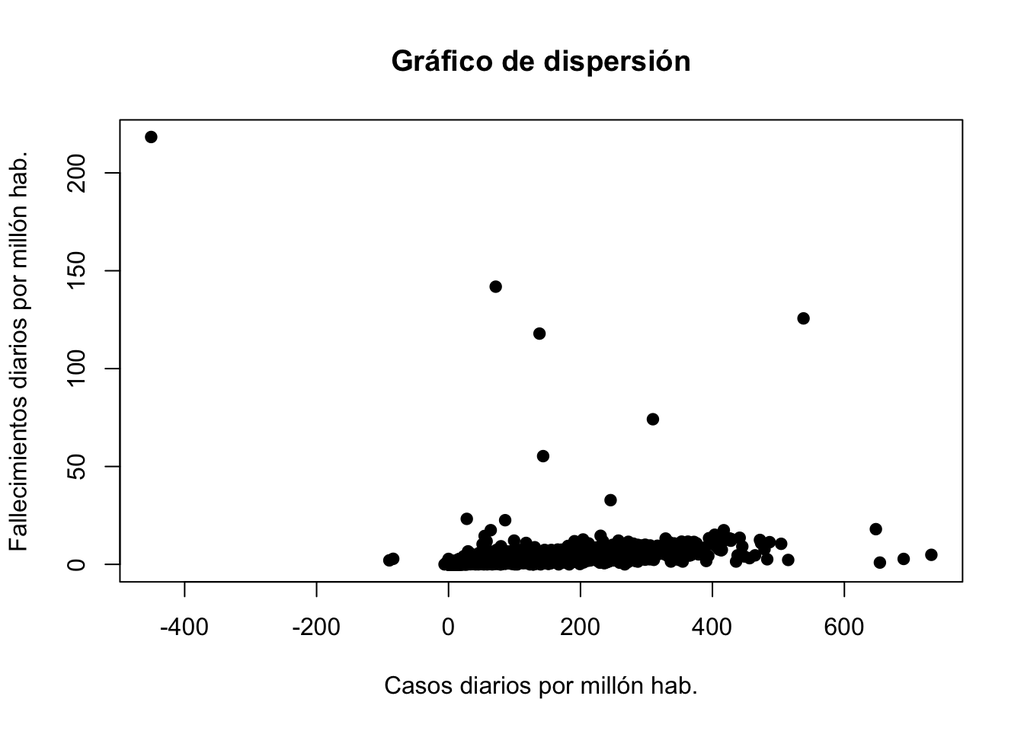

```r
#Crea gráficos de dispersión entre dos vectores.
plot(sud.covid$new_cases_per_million, sud.covid$new_deaths_per_million, main="Gráfico de dispersión",
   xlab="Casos diarios por millón hab.", ylab="Fallecimientos diarios por millón hab.", pch=19)
```

Considerando la cantidad de casos y algunos problemas de nuestra base de datos (p. ej.: días con casos negativos), necesitamos filtrar los *outliers* para poder observar de mejor forma las relaciones. Este procedimiento permite visualizar de mejor forma la relación entre las variables, pero debe utilizarse con mucha precaución, pues básicamente estaremos borrando aquellos reportes que incorporaban muchos nuevos casos y/o fallecimientos y que, por tanto, puede resultar ser información de gran valor. En este caso vamos a quedarnos con aquellos reportes diarios por país que tengan valores positivos en la cantidad de nuevos casos por millón, así como aquellos que tengan valores inferiores 600 en esta misma variable y menores a 30 en la cantidad diaria de fallecimientos.

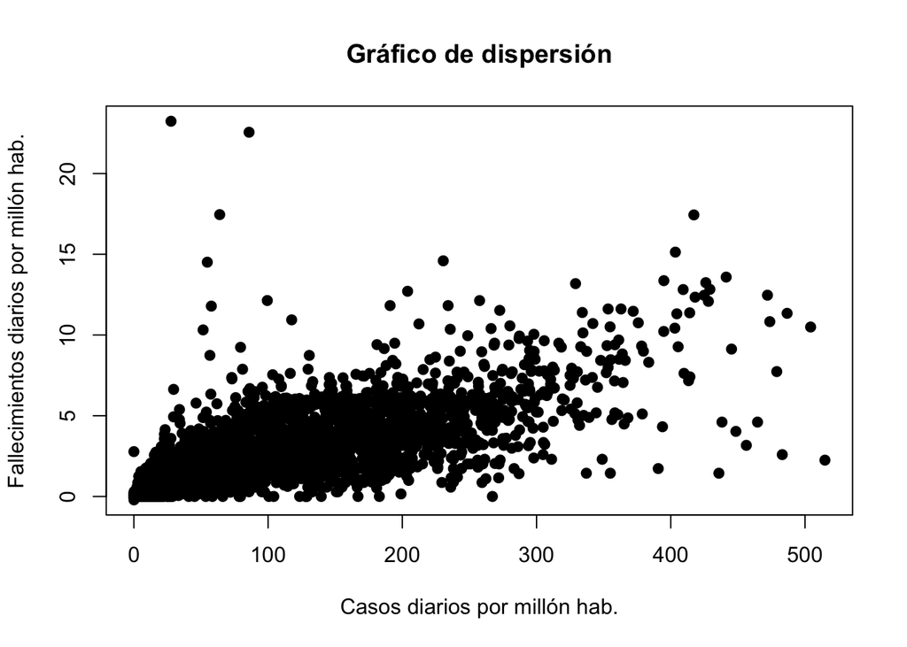

```r
sud.covid <- filter(sud.covid, new_cases_per_million >= 0 & new_cases_per_million <=600 & new_deaths_per_million <= 30)

plot(sud.covid$new_cases_per_million, sud.covid$new_deaths_per_million, main="Gráfico de dispersión",
   xlab="Casos diarios por millón hab.", ylab="Fallecimientos diarios por millón hab.", pch=19)
```

> **¿Puedes observar alguna relación entre las variables? ¿Los puntos en el gráfico se encuentran agrupados o dispersos?**

### 3.2.Coeficiente de correlación de Pearson

Como es probable que a veces los gráficos de dispersión no muestren con claridad una relación, el coeficiente de correlación resulta de gran ayuda, dado que permite cuantificar:

1. la presencia de una relación;
2. la dirección de la relación (directa o inversa); y
3. la fuerza de la relación.

Para obtener el coeficiente de correlación para cada par de variables, se puede utilizar la función “cor()”, pero solo con vectores. Para ello vamos a analizar la relación entre 5 factores:

1. Nuevos casos por millón de habitantes;
2. Nuevos fallecimientos por millón de habitantes;
3. [Índice de Desarrollo Humano](https://dds.cepal.org/infancia/guide-to-estimating-child-poverty/bibliografia/capitulo-III/Calculo%20IDH.pdf)
4. [Producto Interno Bruto per cápita](https://datosmacro.expansion.com/diccionario/pib);
5. Personas vacunadas por cien habitantes.

```r
covid.cor <- subset(sud.covid, select = c(new_cases_per_million, new_deaths_per_million, human_development_index, gdp_per_capita, people_vaccinated_per_hundred))

cor(covid.cor, use="pairwise.complete.obs", method="pearson") #Pairwise nos va a permitir usar toda la información disponible para cada par de variables.
```

```
##                               new_cases_per_million new_deaths_per_million
## new_cases_per_million                     1.0000000             0.76925461
## new_deaths_per_million                    0.7692546             1.00000000
## human_development_index                   0.2698662             0.15766985
## gdp_per_capita                            0.1152882            -0.04585788
## people_vaccinated_per_hundred             0.2903808             0.10202598
##                               human_development_index gdp_per_capita
## new_cases_per_million                       0.2698662     0.11528817
## new_deaths_per_million                      0.1576698    -0.04585788
## human_development_index                     1.0000000     0.78309771
## gdp_per_capita                              0.7830977     1.00000000
## people_vaccinated_per_hundred               0.3995388     0.45825574
##                               people_vaccinated_per_hundred
## new_cases_per_million                             0.2903808
## new_deaths_per_million                            0.1020260
## human_development_index                           0.3995388
## gdp_per_capita                                    0.4582557
## people_vaccinated_per_hundred                     1.0000000
```

```r
#Esta función la podemos correr automáticamente o guardarla dentro de un objeto como se describe a continuación.
correlacion <- cor(covid.cor, use="pairwise.complete.obs", method="pearson")
print(correlacion)
```

```
##                               new_cases_per_million new_deaths_per_million
## new_cases_per_million                     1.0000000             0.76925461
## new_deaths_per_million                    0.7692546             1.00000000
## human_development_index                   0.2698662             0.15766985
## gdp_per_capita                            0.1152882            -0.04585788
## people_vaccinated_per_hundred             0.2903808             0.10202598
##                               human_development_index gdp_per_capita
## new_cases_per_million                       0.2698662     0.11528817
## new_deaths_per_million                      0.1576698    -0.04585788
## human_development_index                     1.0000000     0.78309771
## gdp_per_capita                              0.7830977     1.00000000
## people_vaccinated_per_hundred               0.3995388     0.45825574
##                               people_vaccinated_per_hundred
## new_cases_per_million                             0.2903808
## new_deaths_per_million                            0.1020260
## human_development_index                           0.3995388
## gdp_per_capita                                    0.4582557
## people_vaccinated_per_hundred                     1.0000000
```

### 3.3. Visualización y presentación de información

Finalmente, para aprovechar todas las potencialidades gráficas que ofrece R Studio, recomiendo utilizar una función transferida por el Prof. Juanjo Medina (U. Manchester) sobre el paquete **pairs()**, quien tiene su curso completo escrito en R Markdown y GitHub, abierto y disponible a todo público (pero en inglés): https://jjmedinaariza.github.io/R-for-Criminologists/

Ahora vamos a utilizar esas funciones en el gráfico que nos ofrece *pairs()*:

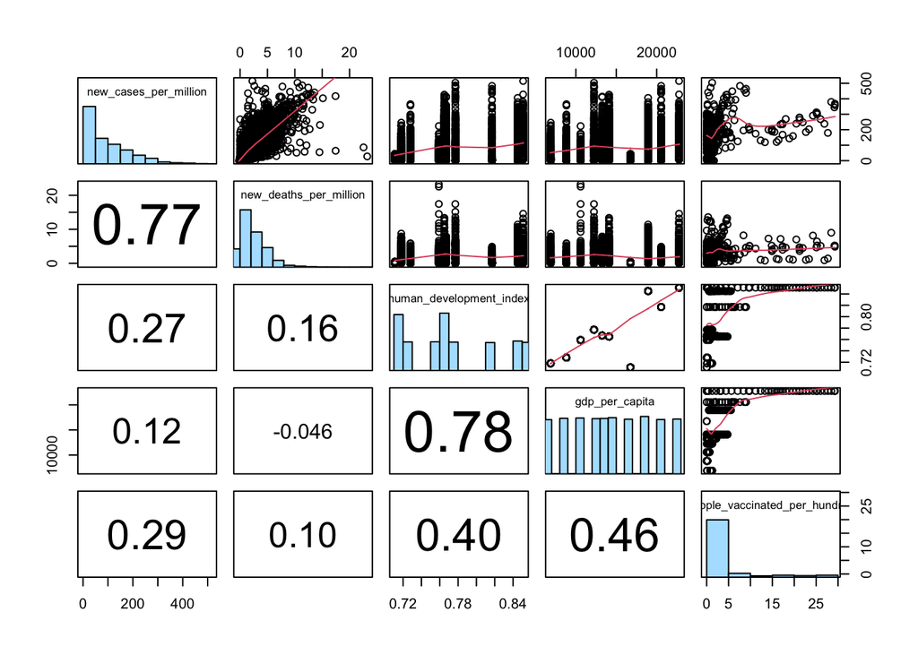

```r
#Aplicación
pairs(covid.cor, upper.panel=panel.smooth, lower.panel=panel.cor, diag.panel=panel.hist)
```

### 3.4. Interpretación de los resultados

> A partir de lo anterior, es posible concluir respecto a la importancia de reducir la cantidad de nuevos contagios para un efectivo control de la pandemia y una disminución de la tasa de letalidad. A la vez, resulta necesario considerar una estrategia regional de inmunización que no condicione el acceso al proceso de vacunación al nivel de riqueza o desarrollo de cada país.

## 4. Ejercicio

### 4.1. Instrucciones

Utilizando la misma base de datos, para esta semana deberá revisar la correlación que existe entre la cantidad de personas vacunadas (por cien) y otras 4 variables que no hayamos utilizado previamente (a elección). Para ello deberá realizar el análisis correlacional siguiendo los pasos descritos anteriormente y responder las consultas que se plantean en la siguiente sección.

### 4.2. Preguntas

1. ¿Por qué eligió esas variables?
2. ¿Qué puede inferir de los gráficos de dispersión?
3. ¿Cuáles son los resultados más relevantes del coeficiente de Pearson?
4. ¿Qué conclusiones puede extraer a partir del análisis correlacional?